# Andrew Y - Case Study 1 EDA

Andrew Yule

2022-06-13

```r
library(tidyverse)
library(maps)
library(gridExtra)
library(lubridate)
library(GGally)
library(jsonlite)
library(class)
library(caret)
library(e1071)
```

# Exploratory data analysis (EDA)

## Data import

### Import the beers and breweries data sets

```r
beers = read_csv("/Users/andrewyule/Dropbox/Personal/SMU MSDS/03 - Doing Data Science/SMU_DDS_CaseStudy1/Data/Beers.csv")
breweries = read_csv("/Users/andrewyule/Dropbox/Personal/SMU MSDS/03 - Doing Data Science/SMU_DDS_CaseStudy1/Data/Breweries.csv")
```

## Analysis questions

### 1. How many breweries are present in each state?

In the data, Colorado was found to have the most number of breweries from the data set (47), followed by California (39), Michigan (32), Oregon (29), and Texas (28). The lowest counted number of breweries was 1, which was found in Washington DC, North Dakota, South Dakota and West Virigina.

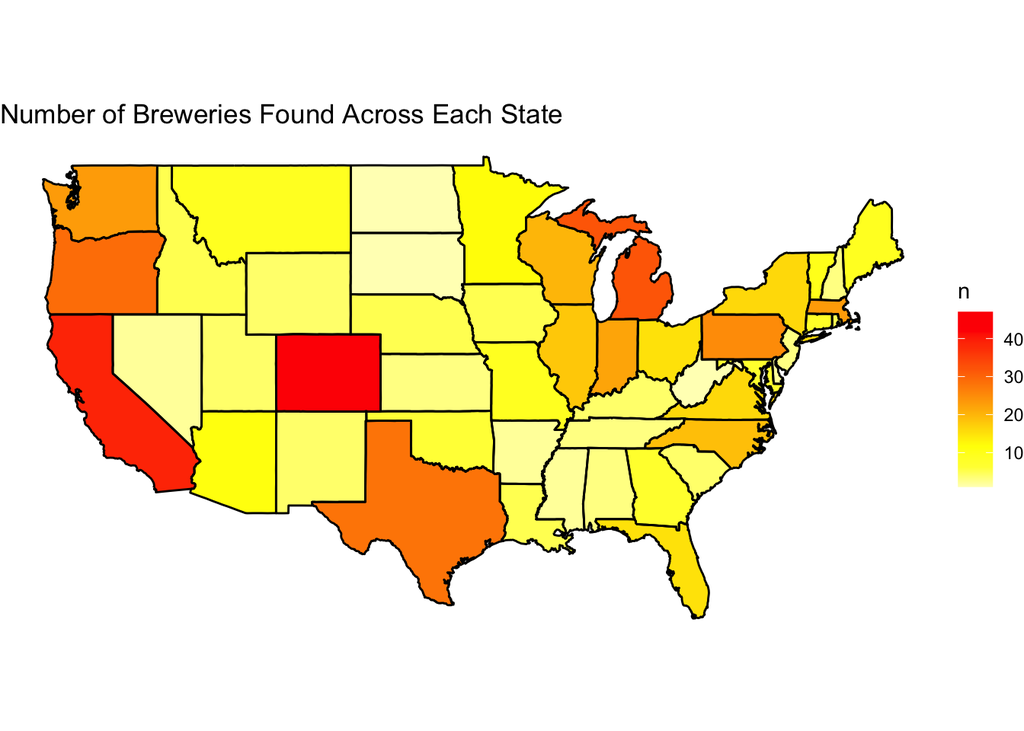

```r
breweryCount = breweries |> count(State)
stateAbbreviations = tibble(abb = state.abb, name = tolower(state.name))
breweryCount = left_join(breweryCount, stateAbbreviations, by = c("State" = "abb"))

states = as_tibble(map_data("state"))
breweryCount = left_join(states, breweryCount, by = c("region" = "name"))
ggplot(breweryCount, aes(x = long, y = lat, group = group))+
  geom_polygon(aes(fill = n))+
  geom_path() +
  scale_fill_gradientn(colours = rev(heat.colors(10)), na.value = "grey90") +
  coord_map() +
  labs(x = NULL, y = NULL, title = "Number of Breweries Found Across Each State") +
  theme_void()
```

What percentage of breweries do the top 5 states make up?

```r
sum(arrange(count(breweries, State), desc(n))[1:5, 2]) / sum(count(breweries, State)[, 2])
```

```
## [1] 0.3136201
```

### 2. Merge the beers and breweries data sets to create a single data set containing both beer information as well as brewery

```r
beers = left_join(beers, breweries, by = c("Brewery_id" = "Brew_ID")) |>
  rename(Beer = Name.x) |>
  rename(Brewery = Name.y)

beers |> head(n = 6)
```

```
## # A tibble: 6 × 10
##   Beer           Beer_ID   ABV   IBU Brewery_id Style Ounces Brewery City  State
##   <chr>            <dbl> <dbl> <dbl>      <dbl> <chr>  <dbl> <chr>   <chr> <chr>
## 1 Pub Beer          1436 0.05     NA        409 Amer…     12 10 Bar… Bend  OR
## 2 Devil's Cup       2265 0.066    NA        178 Amer…     12 18th S… Gary  IN
## 3 Rise of the P…    2264 0.071    NA        178 Amer…     12 18th S… Gary  IN
## 4 Sinister          2263 0.09     NA        178 Amer…     12 18th S… Gary  IN
## 5 Sex and Candy     2262 0.075    NA        178 Amer…     12 18th S… Gary  IN
## 6 Black Exodus      2261 0.077    NA        178 Oatm…     12 18th S… Gary  IN
```

```r
beers |> tail(n = 6)
```

```
## # A tibble: 6 × 10
##   Beer           Beer_ID   ABV   IBU Brewery_id Style Ounces Brewery City  State
##   <chr>            <dbl> <dbl> <dbl>      <dbl> <chr>  <dbl> <chr>   <chr> <chr>
## 1 Rocky Mountai…    1035 0.075    NA        425 Amer…     12 Wynkoo… Denv… CO
## 2 Belgorado          928 0.067    45        425 Belg…     12 Wynkoo… Denv… CO
## 3 Rail Yard Ale      807 0.052    NA        425 Amer…     12 Wynkoo… Denv… CO
## 4 B3K Black Lag…     620 0.055    NA        425 Schw…     12 Wynkoo… Denv… CO
## 5 Silverback Pa…     145 0.055    40        425 Amer…     12 Wynkoo… Denv… CO
## 6 Rail Yard Ale…      84 0.052    NA        425 Amer…     12 Wynkoo… Denv… CO
```

### 3. Address the missing values in each column.

The only columns from the data set containing missing entries are ABV (alcohol by volume), IBU (international bitterness units), and Style. The highest number of missing values was found for the IBU variable (42% of values are missing).

```r
(colSums(is.na(beers))/dim(beers)[1])*100
```

```
##       Beer    Beer_ID        ABV        IBU Brewery_id      Style     Ounces
##  0.0000000  0.0000000  2.5726141 41.7012448  0.0000000  0.2074689  0.0000000
##    Brewery       City      State
##  0.0000000  0.0000000  0.0000000
```

### 4. / 5. Compute the median alcohol content and international bitterness unit for each state. Plot a bar chart to compare. Which state has the maximum alcoholic (ABV) beer? Which state has the most bitter (IBU) beer?

The median alcohol by volume (ABV) across the states varies between 0.04 (Utah) and 0.0625 (Washington DC & Kentucky). The median international bitterness unit (IBU) varies between 19 (Wisconsin) and 61 (Maine).

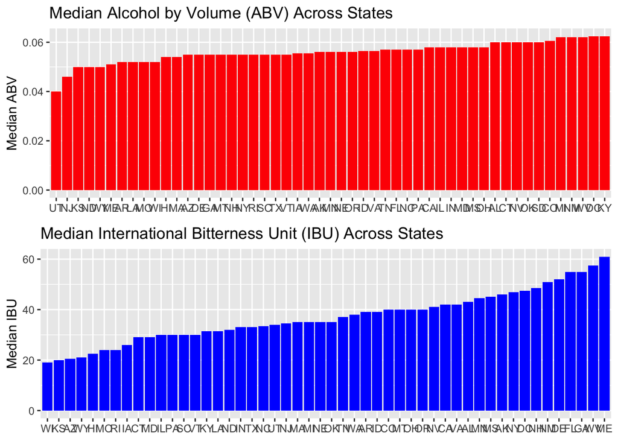

```r
medianABV = beers |>
  filter(!is.na(ABV)) |>
  group_by(State) |>
  summarize(ABV = median(ABV))

medianIBU = beers |>
  filter(!is.na(IBU)) |>
  group_by(State) |>
  summarize(IBU = median(IBU))

p1 = medianABV |>
  ggplot(aes(x = reorder(State, ABV), y = ABV)) +
  geom_col(fill = "red") +
  labs(y = "Median ABV", x = NULL, title = "Median Alcohol by Volume (ABV) Across States")

p2 = medianIBU |>
  ggplot(aes(x = reorder(State, IBU), y = IBU)) +
  geom_col(fill = "blue") +
  labs(y = "Median IBU", x = NULL, title = "Median International Bitterness Unit (IBU) Across States")

grid.arrange(p1, p2)
```

The absolute maximum ABV and IBU for any state

```r
slice_max(beers, ABV, n = 1)
```

```
## # A tibble: 1 × 10
##   Beer           Beer_ID   ABV   IBU Brewery_id Style Ounces Brewery City  State
##   <chr>            <dbl> <dbl> <dbl>      <dbl> <chr>  <dbl> <chr>   <chr> <chr>
## 1 Lee Hill Seri…    2565 0.128    NA         52 Quad…   19.2 Upslop… Boul… CO
```

```r
slice_max(beers, IBU, n = 1)
```

```
## # A tibble: 1 × 10
##   Beer           Beer_ID   ABV   IBU Brewery_id Style Ounces Brewery City  State
##   <chr>            <dbl> <dbl> <dbl>      <dbl> <chr>  <dbl> <chr>   <chr> <chr>
## 1 Bitter Bitch …     980 0.082   138        375 Amer…     12 Astori… Asto… OR
```

### 6. Comment on the summary statistics and distribution of the ABV variable.

Overall, the average ABV is around 0.059, with a minimum and maximum reported value of 0.001 and 0.128 respectively. The distribution of ABV is right skewed, meaning there are a few beers with very high alcohol contents increasing the mean ABV compared to the median ABV.

```r
beers |>
  select(ABV) |>
  summary()
```

```
##       ABV
##  Min.   :0.00100
##  1st Qu.:0.05000
##  Median :0.05600
##  Mean   :0.05977
##  3rd Qu.:0.06700
##  Max.   :0.12800
##  NA's   :62
```

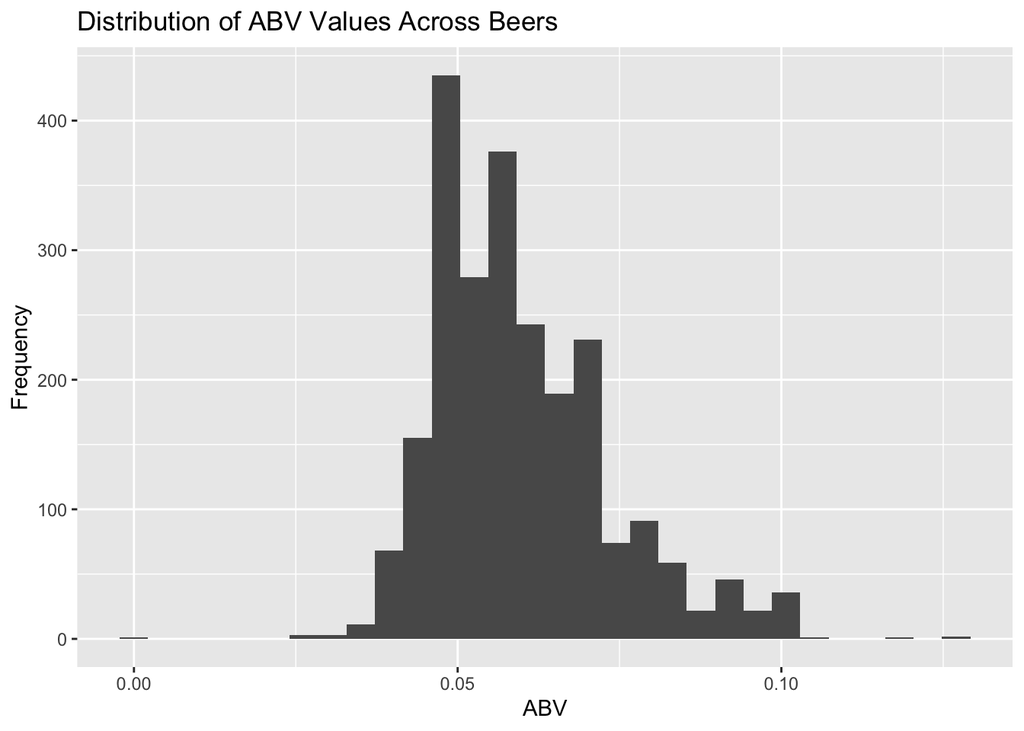

```r
beers |>
  ggplot(aes(x = ABV)) +
  geom_histogram() +
  labs(x = "ABV", y = "Frequency", title = "Distribution of ABV Values Across Beers")
```

### 7. Is there an apparent relationship between the bitterness of the beer and its alcoholic content? Draw a scatter plot. Make your best judgment of a relationship and EXPLAIN your answer.

The scatterplot between IBU and ABV shows that there is a positive correlation (0.67), meaning that as IBU increases, it is expected that ABV increases as well.

```r
cor(beers[!is.na(beers$ABV) & !is.na(beers$IBU),]$IBU, beers[!is.na(beers$ABV) & !is.na(beers$IBU),]$ABV)
```

```
## [1] 0.6706215
```

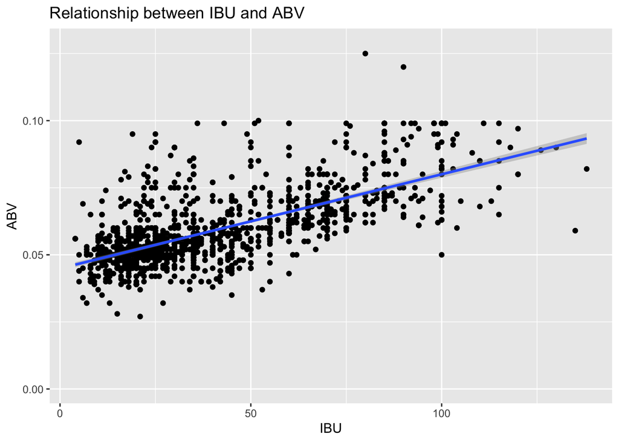

```r
beers |>
  ggplot(aes(x = IBU, y = ABV)) +
  geom_point() +
  geom_smooth(method = "lm") +
  labs(x = "IBU", y = "ABV", title = "Relationship between IBU and ABV")
```